```python
V = (ord('Г') + ord('Д')) % 11
print("Вариант: "+ str(V))
```

```
Вариант: 8
```

# 1. Описание набора

```python
import pandas as pd
data = pd.read_csv("Myocardial infarction complications Database.csv")
data.head()
```

|  | ID | AGE | SEX | INF_ANAM | STENOK_AN | FK_STENOK | IBS_POST | IBS_NASL | GB | SIM_GIPERT | ... | JELUD_TAH | FIBR_JELUD | A_V_BLOK | OTEK_LANC | RAZRIV | DRESSLER | ZSN | REC_IM | P_IM_STEN | LET_IS |
| --- | --- | --- | --- | --- | --- | --- | --- | --- | --- | --- | --- | --- | --- | --- | --- | --- | --- | --- | --- | --- | --- |
| 0 | 1 | 77.0 | 1 | 2.0 | 1.0 | 1.0 | 2.0 | NaN | 3.0 | 0.0 | ... | 0 | 0 | 0 | 0 | 0 | 0 | 0 | 0 | 0 | 0 |
| 1 | 2 | 55.0 | 1 | 1.0 | 0.0 | 0.0 | 0.0 | 0.0 | 0.0 | 0.0 | ... | 0 | 0 | 0 | 0 | 0 | 0 | 0 | 0 | 0 | 0 |
| 2 | 3 | 52.0 | 1 | 0.0 | 0.0 | 0.0 | 2.0 | NaN | 2.0 | 0.0 | ... | 0 | 0 | 0 | 0 | 0 | 0 | 0 | 0 | 0 | 0 |
| 3 | 4 | 68.0 | 0 | 0.0 | 0.0 | 0.0 | 2.0 | NaN | 2.0 | 0.0 | ... | 0 | 0 | 0 | 0 | 0 | 0 | 1 | 0 | 0 | 0 |
| 4 | 5 | 60.0 | 1 | 0.0 | 0.0 | 0.0 | 2.0 | NaN | 3.0 | 0.0 | ... | 0 | 0 | 0 | 0 | 0 | 0 | 0 | 0 | 0 | 0 |

5 rows × 124 columns

```python
data.info()
```

```
<class 'pandas.core.frame.DataFrame'>
RangeIndex: 1700 entries, 0 to 1699
Columns: 124 entries, ID to LET_IS
dtypes: float64(110), int64(14)
memory usage: 1.6 MB
```

Датасет Myocardial infarction complications содержит клинические данные пациентов, перенёсших инфаркт миокарда. Он используется для анализа факторов риска, диагностики, прогнозирования осложнений и летальных исходов.

В датасете содержатся данные о 1700 пациентах со 124 признаками. Присутствуют пропуски. Типы данных:

- float64 — 110 признаков (медицинские показатели, лабораторные результаты, баллы состояния)
- int64 — 14 признаков (категориальные или бинарные индикаторы)

Датасет был использован в работе Trajectories, bifurcations, and pseudo-time in large clinical datasets: applications to myocardial infarction and diabetes data (https://www.semanticscholar.org/paper/Trajectories%2C-bifurcations%2C-and-pseudo-time-in-to-Golovenkin-Bac/0ea5a469d4f0d83ce6a0d2f7215269877afaf628). В статье авторы предлагают полусупервизированную методологию для анализа больших клинических наборов данных, отличающихся смешанностью типов признаков (непрерывные, бинарные, порядковые) и наличием пропущенных значений. Главная идея — рассматривать синхронные (одноразовые) клинические наблюдения как часть буке́та ветвящихся траекторий развития болезни, и вводить понятие псевдовремени (pseudo-time), который отражает «продвижение» пациента вдоль одной из возможных траекторий.

# 2. Построение модели DecisionTreeClassifier

## Предобработка данных, разделение набора на тестовую и обучающую выборки

```python
import numpy as np
from sklearn.model_selection import train_test_split
from sklearn.tree import DecisionTreeClassifier, plot_tree
from sklearn.metrics import accuracy_score, confusion_matrix, ConfusionMatrixDisplay
import matplotlib.pyplot as plt
import seaborn as sns

data = data.drop(columns=['ID'], errors='ignore')

target = 'LET_IS'

data = data.dropna(subset=[target])

data = data.fillna(data.median())

X = data.drop(columns=[target])
y = data[target]

X_train, X_test, y_train, y_test = train_test_split(
    X, y, test_size=0.3, random_state=94, stratify=y
)

print("Размер обучающей выборки:", X_train.shape)
print("Размер тестовой выборки:", X_test.shape)
```

```
Размер обучающей выборки: (1190, 122)
Размер тестовой выборки: (510, 122)
```

## Построение полного дерева решений без ограничений

```
Точность полного дерева: 0.8450980392156863
```

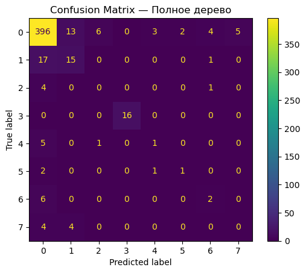

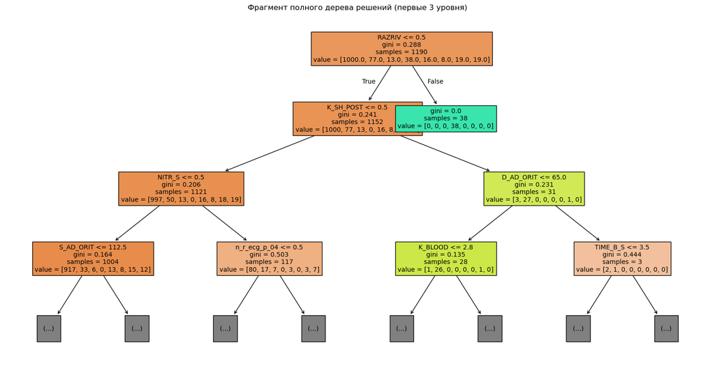

```python
DTC_full = DecisionTreeClassifier(random_state=94)
DTC_full.fit(X_train, y_train)

y_pred_full = DTC_full.predict(X_test)

print("Точность полного дерева:", accuracy_score(y_test, y_pred_full))

ConfusionMatrixDisplay.from_estimator(DTC_full, X_test, y_test)
plt.title("Confusion Matrix — Полное дерево")
plt.show()

plt.figure(figsize=(20, 10))
plot_tree(DTC_full, feature_names=X.columns, filled=True, max_depth=3, fontsize=10)
plt.title("Фрагмент полного дерева решений (первые 3 уровня)")
plt.show()
```

## Исследование влияния гиперпараметров

### Влияние числа уровней дерева

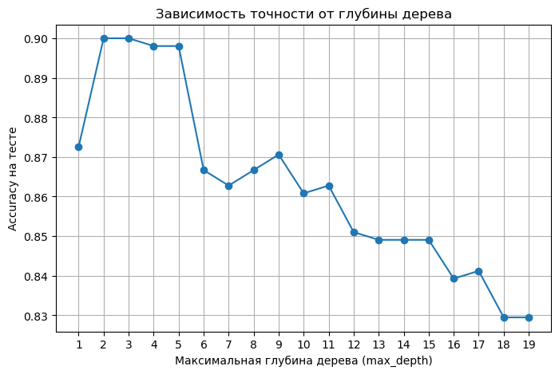

```python
depth_values = range(1, 20)
acc_scores = []

for d in depth_values:
    clf = DecisionTreeClassifier(max_depth=d, random_state=42)
    clf.fit(X_train, y_train)
    y_pred = clf.predict(X_test)
    acc_scores.append(accuracy_score(y_test, y_pred))

plt.figure(figsize=(8,5))
plt.plot(depth_values, acc_scores, marker='o')
plt.xlabel("Максимальная глубина дерева (max_depth)")
plt.ylabel("Accuracy на тесте")
plt.title("Зависимость точности от глубины дерева")

plt.xticks(depth_values)

plt.grid(True)
plt.show()
```

### Влияние минимального числа объектов узла

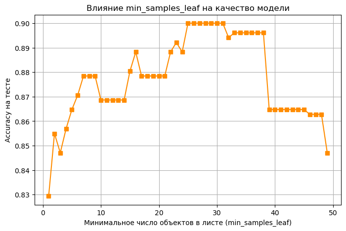

```python
leaf_values = range(1, 50)
acc_leaf = []

for leaf in leaf_values:
    clf = DecisionTreeClassifier(min_samples_leaf=leaf, random_state=42)
    clf.fit(X_train, y_train)
    y_pred = clf.predict(X_test)
    acc_leaf.append(accuracy_score(y_test, y_pred))

plt.figure(figsize=(8,5))
plt.plot(leaf_values, acc_leaf, marker='s', color='darkorange')
plt.xlabel("Минимальное число объектов в листе (min_samples_leaf)")
plt.ylabel("Accuracy на тесте")
plt.title("Влияние min_samples_leaf на качество модели")

plt.grid(True)
plt.show()
```

### Сравнительный анализ с полным деревом

```
Лучшие результаты по глубине дерева (max_depth):
```

|  | max_depth | accuracy |
| --- | --- | --- |
| 2 | 3 | 0.900000 |
| 1 | 2 | 0.900000 |
| 3 | 4 | 0.898039 |
| 4 | 5 | 0.898039 |
| 0 | 1 | 0.872549 |
| 8 | 9 | 0.870588 |
| 5 | 6 | 0.866667 |
| 7 | 8 | 0.866667 |
| 10 | 11 | 0.862745 |
| 6 | 7 | 0.862745 |

```
Лучшие результаты по минимальному числу объектов в листе (min_samples_leaf):
```

|  | min_samples_leaf | accuracy |
| --- | --- | --- |
| 24 | 25 | 0.900000 |
| 30 | 31 | 0.900000 |
| 29 | 30 | 0.900000 |
| 28 | 29 | 0.900000 |
| 27 | 28 | 0.900000 |
| 26 | 27 | 0.900000 |
| 25 | 26 | 0.900000 |
| 37 | 38 | 0.896078 |
| 36 | 37 | 0.896078 |
| 35 | 36 | 0.896078 |

```
Точность полного дерева: 0.8450980392156863
Точность дерева с оптимальными параметрами: 0.9
```

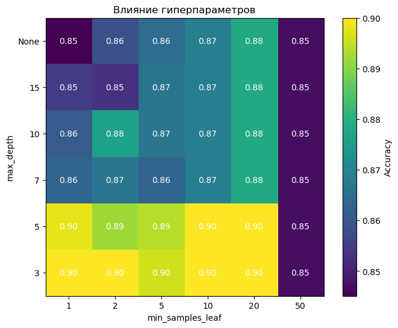

```python
results_depth = pd.DataFrame({
    "max_depth": list(range(1, 20)),
    "accuracy": acc_scores
}).sort_values(by="accuracy", ascending=False)

print("Лучшие результаты по глубине дерева (max_depth):")
display(results_depth.head(10))

best_depth = int(results_depth.iloc[0]['max_depth'])

results_leaf = pd.DataFrame({
    "min_samples_leaf": list(range(1, 50)),
    "accuracy": acc_leaf
}).sort_values(by="accuracy", ascending=False)

print("Лучшие результаты по минимальному числу объектов в листе (min_samples_leaf):")
display(results_leaf.head(10))

best_leaf = int(results_leaf.iloc[0]['min_samples_leaf'])

DTC_best = DecisionTreeClassifier(
    max_depth=3,
    min_samples_leaf=best_leaf,
    random_state=94
)
DTC_best.fit(X_train, y_train)
y_pred_best = DTC_best.predict(X_test)

print("Точность полного дерева:", accuracy_score(y_test, y_pred_full))
print("Точность дерева с оптимальными параметрами:",
      accuracy_score(y_test, y_pred_best))


depth_values = [3, 5, 7, 10, 15, None]
leaf_values = [1, 2, 5, 10, 20, 50]

results = np.zeros((len(depth_values), len(leaf_values)))

for i, depth in enumerate(depth_values):
    for j, leaf in enumerate(leaf_values):
        clf = DecisionTreeClassifier(max_depth=depth, min_samples_leaf=leaf, random_state=94)
        clf.fit(X_train, y_train)
        acc = accuracy_score(y_test, clf.predict(X_test))
        results[i, j] = acc

plt.figure(figsize=(8, 6))
im = plt.imshow(results, cmap='viridis', origin='lower')

plt.xticks(ticks=range(len(leaf_values)), labels=leaf_values)
plt.yticks(ticks=range(len(depth_values)), labels=[str(d) for d in depth_values])
plt.xlabel("min_samples_leaf")
plt.ylabel("max_depth")
plt.title("Влияние гиперпараметров")

for i in range(len(depth_values)):
    for j in range(len(leaf_values)):
        plt.text(j, i, f"{results[i, j]:.2f}", ha='center', va='center', color='white')

plt.colorbar(im, label="Accuracy")
plt.show()
```

# 3. Построение структуры дерева решений для выбранной модели, указание показателей, участвующих в структуре дерева

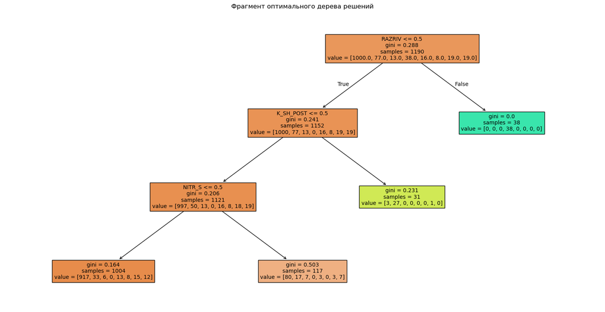

```python
plt.figure(figsize=(20, 10))
plot_tree(DTC_best, feature_names=X.columns, filled=True, fontsize=10)
plt.title("Фрагмент оптимального дерева решений")
plt.show()
```

Показатели, участвующие в структуре дерева:

- RAZRIV - разрыв миокарда (тип - бинарный)
- K_SH_POST - Кардиогенный шок при поступлении в отделение интенсивной терапии (тип - бинарный)
- NITR_S - Использование жидких нитратов в отделении интенсивной терапии (тип - бинарный)

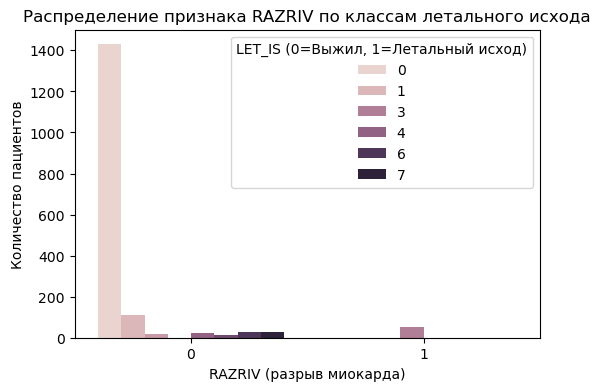

```python
plt.figure(figsize=(6,4))
sns.countplot(x='RAZRIV', hue='LET_IS', data=data)
plt.title("Распределение признака RAZRIV по классам летального исхода")
plt.xlabel("RAZRIV (разрыв миокарда)")
plt.ylabel("Количество пациентов")
plt.legend(title="LET_IS (0=Выжил, 1=Летальный исход)")
plt.show()
```

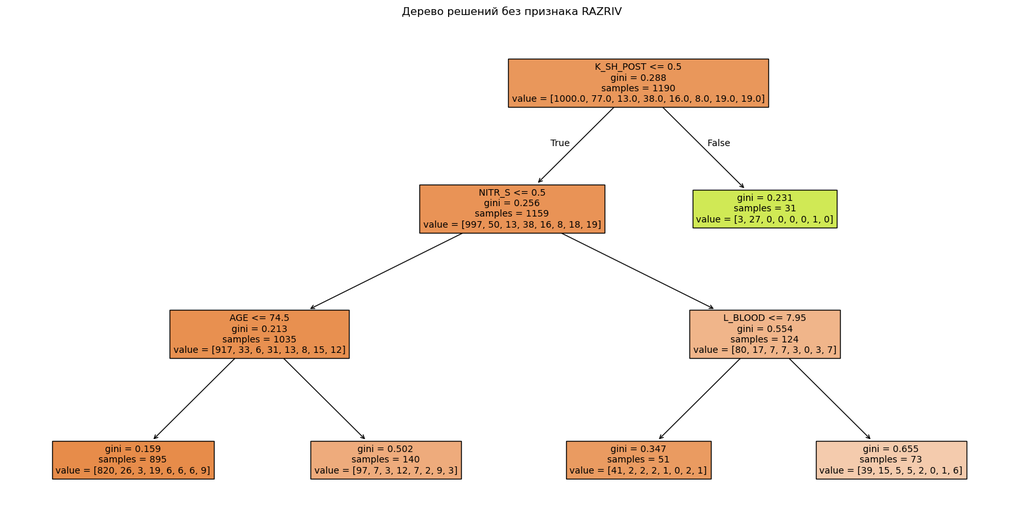

```
Точность модели с RAZRIV: 0.9
Точность модели без RAZRIV: 0.8686274509803922
```

```python
X_no_razriv = X.drop(columns=['RAZRIV'], errors='ignore')

X_train2, X_test2, y_train2, y_test2 = train_test_split(
    X_no_razriv, y, test_size=0.3, random_state=94, stratify=y
)

DTC_no_razriv = DecisionTreeClassifier(
    max_depth=3,
    min_samples_leaf=best_leaf,
    random_state=94
)
DTC_no_razriv.fit(X_train2, y_train2)

plt.figure(figsize=(20, 10))
plot_tree(DTC_no_razriv, feature_names=X_no_razriv.columns, filled=True, fontsize=10)
plt.title("Дерево решений без признака RAZRIV")
plt.show()

y_pred_with = DTC_best.predict(X_test)
y_pred_without = DTC_no_razriv.predict(X_test2)

print("Точность модели с RAZRIV:", accuracy_score(y_test, y_pred_with))
print("Точность модели без RAZRIV:", accuracy_score(y_test2, y_pred_without))
```

Эксперимент показал, что парметр RAZRIV является достаточно важным при построении DTC. Результатом исключения его из набора и построения дерева с наилучшими параметрами, выявленными в п.2 стало ухудшение оценки точности модели на ~0.0314

# 4. Построение модели RandomForest

```
Точность базового Random Forest: 0.8960784313725491
```

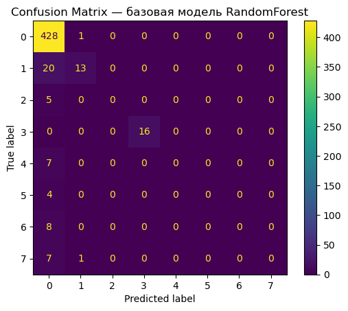

```python
from sklearn.ensemble import RandomForestClassifier

rf = RandomForestClassifier(random_state=94)
rf.fit(X_train, y_train)

y_pred_rf = rf.predict(X_test)
print("Точность базового Random Forest:", accuracy_score(y_test, y_pred_rf))

ConfusionMatrixDisplay.from_estimator(rf, X_test, y_test)
plt.title("Confusion Matrix — базовая модель RandomForest")
plt.show()
```

## Исследование влияния гиперпараметров

### Влияние числа деревьев

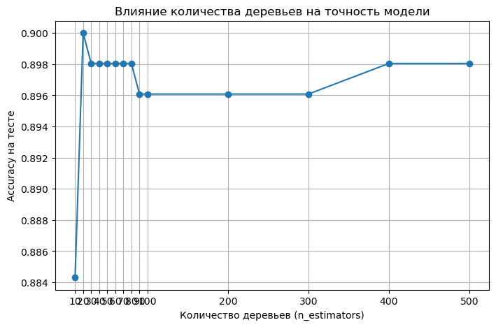

```python
n_values = [10, 20, 30, 40,  50, 60, 70 , 80 , 90, 100, 200, 300, 400, 500]
acc_values = []

for n in n_values:
    model = RandomForestClassifier(n_estimators=n, random_state=94, n_jobs=-1)
    model.fit(X_train, y_train)
    y_pred = model.predict(X_test)
    acc_values.append(accuracy_score(y_test, y_pred))

plt.figure(figsize=(8,5))
plt.plot(n_values, acc_values, marker='o')
plt.xlabel("Количество деревьев (n_estimators)")
plt.ylabel("Accuracy на тесте")
plt.title("Влияние количества деревьев на точность модели")

plt.xticks(n_values)

plt.grid(True)
plt.show()
```

### Влияние числа отбираемых показателей

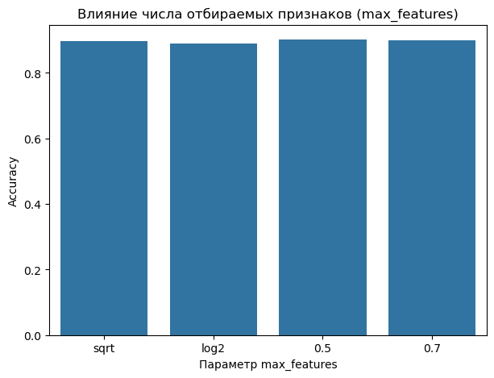

```python
feature_opts = ['sqrt', 'log2', 0.5, 0.7, None]
acc_features = []

for f in feature_opts:
    model = RandomForestClassifier(n_estimators=100, max_features=f, random_state=94)
    model.fit(X_train, y_train)
    y_pred = model.predict(X_test)
    acc_features.append(accuracy_score(y_test, y_pred))

plt.figure(figsize=(7,5))
sns.barplot(x=feature_opts, y=acc_features)
plt.title("Влияние числа отбираемых признаков (max_features)")
plt.xlabel("Параметр max_features")
plt.ylabel("Accuracy")
plt.show()
```

### Влияние построения полных или ограниченных деревьев

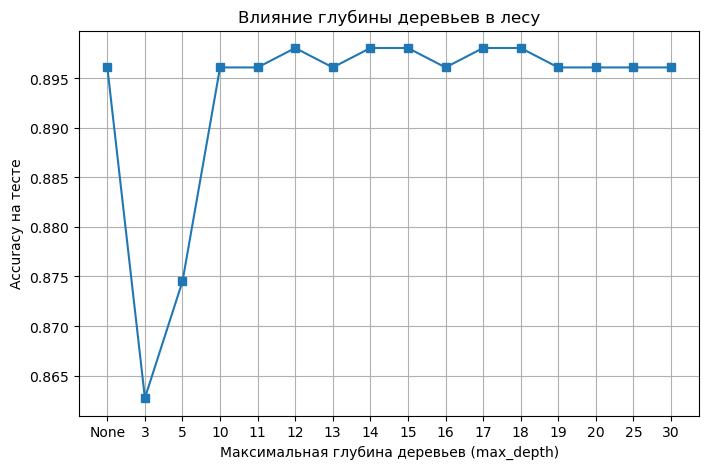

```python
depths = [None, 3, 5, 10, 11, 12, 13, 14, 15, 16, 17, 18, 19, 20, 25, 30]
acc_depths = []

for d in depths:
    model = RandomForestClassifier(n_estimators=100, max_depth=d, random_state=42)
    model.fit(X_train, y_train)
    y_pred = model.predict(X_test)
    acc_depths.append(accuracy_score(y_test, y_pred))

plt.figure(figsize=(8,5))
plt.plot([str(d) for d in depths], acc_depths, marker='s')
plt.xlabel("Максимальная глубина деревьев (max_depth)")
plt.ylabel("Accuracy на тесте")
plt.title("Влияние глубины деревьев в лесу")
plt.grid(True)
plt.show()
```

## Построение оптимальной модели

```
Точность выбранной модели: 0.9
```

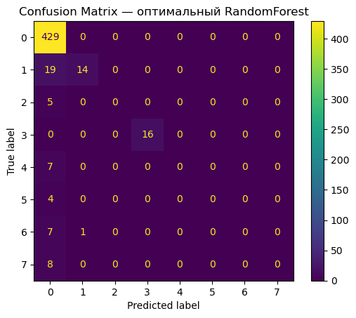

```python
rf_best = RandomForestClassifier(
    n_estimators=20,
    max_depth=12,
    max_features='sqrt',
    random_state=94
)
rf_best.fit(X_train, y_train)

y_pred_best = rf_best.predict(X_test)
print("Точность выбранной модели:", accuracy_score(y_test, y_pred_best))

ConfusionMatrixDisplay.from_estimator(rf_best, X_test, y_test)
plt.title("Confusion Matrix — оптимальный RandomForest")
plt.show()
```

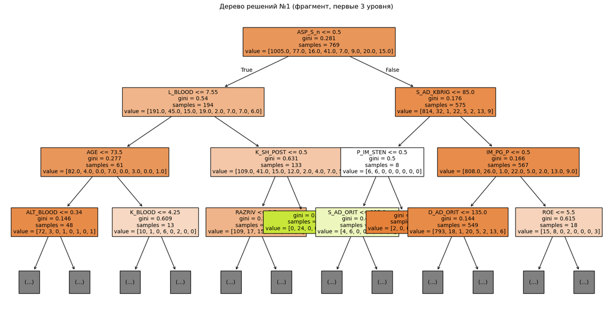

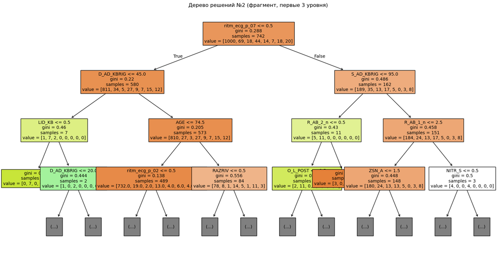

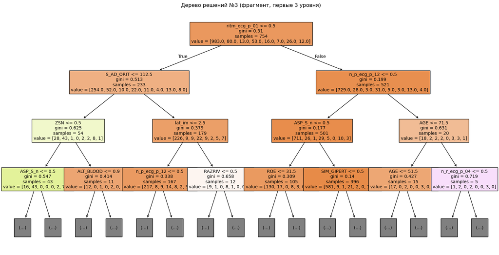

```python
estimators = rf_best.estimators_[:3]

for i, tree in enumerate(estimators, 1):
    plt.figure(figsize=(20, 10))
    plot_tree(tree, feature_names=X.columns, filled=True, max_depth=3, fontsize=10)
    plt.title(f"Дерево решений №{i} (фрагмент, первые 3 уровня)")
    plt.show()
```

# 5. Получение оценок важности показателей с помощью модели RandomForest

```python
importances = pd.Series(rf_best.feature_importances_, index=X.columns)

importances_sorted = importances.sort_values(ascending=False)

print("Топ-10 наиболее важных признаков:")
display(importances_sorted.head(10))
```

```
Топ-10 наиболее важных признаков:
```

```
RAZRIV        0.134130
D_AD_ORIT     0.051786
S_AD_ORIT     0.049993
K_SH_POST     0.043281
AGE           0.036265
ZSN_A         0.027758
L_BLOOD       0.026777
K_BLOOD       0.026273
S_AD_KBRIG    0.026001
D_AD_KBRIG    0.025636
dtype: float64
```

```
Три наиболее значимых признака: ['RAZRIV', 'D_AD_ORIT', 'S_AD_ORIT']
```

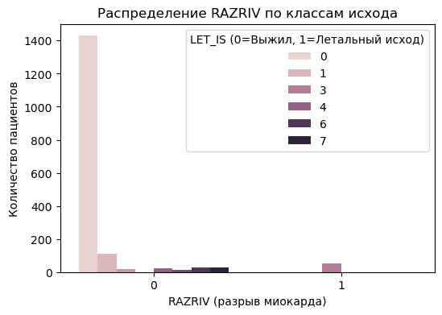

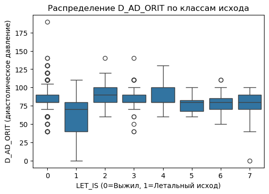

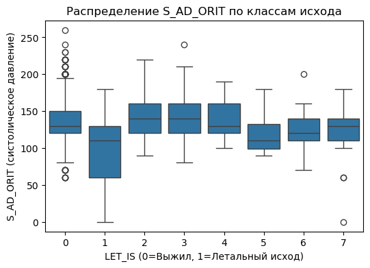

```python
top3 = importances_sorted.head(3).index.tolist()
print("Три наиболее значимых признака:", top3)

plt.figure(figsize=(6, 4))
sns.countplot(x="RAZRIV", hue="LET_IS", data=data)
plt.title("Распределение RAZRIV по классам исхода")
plt.xlabel("RAZRIV (разрыв миокарда)")
plt.ylabel("Количество пациентов")
plt.legend(title="LET_IS (0=Выжил, 1=Летальный исход)")
plt.show()

plt.figure(figsize=(6, 4))
sns.boxplot(x="LET_IS", y="D_AD_ORIT", data=data)
plt.title("Распределение D_AD_ORIT по классам исхода")
plt.xlabel("LET_IS (0=Выжил, 1=Летальный исход)")
plt.ylabel("D_AD_ORIT (диастолическое давление)")
plt.show()

plt.figure(figsize=(6, 4))
sns.boxplot(x="LET_IS", y="S_AD_ORIT", data=data)
plt.title("Распределение S_AD_ORIT по классам исхода")
plt.xlabel("LET_IS (0=Выжил, 1=Летальный исход)")
plt.ylabel("S_AD_ORIT (систолическое давление)")
plt.show()
```

# 6.Построение трех моделей классификации RandomForest на разном наборе показателей

```python
importances = pd.Series(rf_best.feature_importances_, index=X.columns).sort_values(ascending=False)

top_30_count = int(len(importances) * 0.3)

X_full = X.copy()
X_top = X[importances.head(top_30_count).index]
X_low = X[importances.tail(top_30_count).index]

print(f"Полный набор признаков: {X_full.shape[1]}")
print(f"Наиболее важные 30% признаков: {X_top.shape[1]}")
print(f"Наименее важные 30% признаков: {X_low.shape[1]}")
```

```
Полный набор признаков: 122
Наиболее важные 30% признаков: 36
Наименее важные 30% признаков: 36
```

```python
def train_rf_and_evaluate(X_train, X_test, y_train, y_test):
    model = RandomForestClassifier(
        n_estimators=100,
        max_depth=None,
        max_features='sqrt',
        random_state=94
    )
    model.fit(X_train, y_train)
    y_pred = model.predict(X_test)
    return accuracy_score(y_test, y_pred)

X_train_full, X_test_full, y_train, y_test = train_test_split(X_full, y, test_size=0.3, random_state=94, stratify=y)

acc_full = train_rf_and_evaluate(X_train_full, X_test_full, y_train, y_test)

acc_top = train_rf_and_evaluate(
    X_train_full[X_top.columns],
    X_test_full[X_top.columns],
    y_train,
    y_test
)

acc_low = train_rf_and_evaluate(
    X_train_full[X_low.columns],
    X_test_full[X_low.columns],
    y_train,
    y_test
)

results = pd.DataFrame({
    "Набор признаков": ["Полный", "Наиболее важные 30%", "Наименее важные 30%"],
    "Число признаков": [X_full.shape[1], X_top.shape[1], X_low.shape[1]],
    "Точность модели": [acc_full, acc_top, acc_low]
})

display(results)
```

|  | Набор признаков | Число признаков | Точность модели |
| --- | --- | --- | --- |
| 0 | Полный | 122 | 0.896078 |
| 1 | Наиболее важные 30% | 36 | 0.898039 |
| 2 | Наименее важные 30% | 36 | 0.839216 |

# 7. Построить модели с бустингом

|  | Число деревьев | Точность на обучении | Точность на тесте |
| --- | --- | --- | --- |
| 0 | 5 | 0.855462 | 0.854902 |
| 1 | 10 | 0.866387 | 0.872549 |
| 2 | 20 | 0.849580 | 0.856863 |
| 3 | 50 | 0.873950 | 0.849020 |
| 4 | 100 | 0.897479 | 0.880392 |
| 5 | 200 | 0.910924 | 0.884314 |
| 6 | 300 | 0.919328 | 0.882353 |
| 7 | 500 | 0.921008 | 0.898039 |
| 8 | 600 | 0.923529 | 0.896078 |
| 9 | 800 | 0.923529 | 0.894118 |
| 10 | 1000 | 0.928571 | 0.894118 |

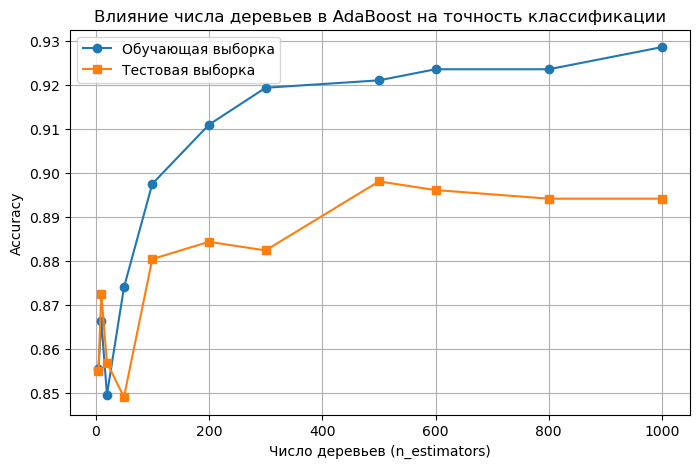

```python
from sklearn.ensemble import AdaBoostClassifier
from sklearn.metrics import accuracy_score

n_estimators_list = [5, 10, 20, 50, 100, 200, 300, 500, 600, 800, 1000]

train_scores = []
test_scores = []

for n in n_estimators_list:
    ada = AdaBoostClassifier(
        estimator=DTC_best,
        n_estimators=n,
        random_state=94
    )
    ada.fit(X_train, y_train)

    y_train_pred = ada.predict(X_train)
    y_test_pred = ada.predict(X_test)

    train_scores.append(accuracy_score(y_train, y_train_pred))
    test_scores.append(accuracy_score(y_test, y_test_pred))

results_ada = pd.DataFrame({
    "Число деревьев": n_estimators_list,
    "Точность на обучении": train_scores,
    "Точность на тесте": test_scores
})

display(results_ada)

plt.figure(figsize=(8,5))
plt.plot(n_estimators_list, train_scores, marker='o', label='Обучающая выборка')
plt.plot(n_estimators_list, test_scores, marker='s', label='Тестовая выборка')
plt.title("Влияние числа деревьев в AdaBoost на точность классификации")
plt.xlabel("Число деревьев (n_estimators)")
plt.ylabel("Accuracy")
plt.legend()
plt.grid(True)
plt.show()
```

Оптимальное число деревьев: ~500 Максимальная точность на тесте: 0.898

Вывод:

1. При малом числе деревьев точность может быть низкой из-за недостаточного обучения.
2. При увеличении n_estimators модель стабилизируется, но прирост точности со временем снижается.